# Defenders

### Выбор ролей защитников

Для лучшего выбора ролей защитников был проведен анализ всех игровых моментов. Для каждого игрового момента был добавлен критерий успешной атаки ‘success’, который принимает два значения 1 или 0.

- 1 – атака успешна, атакующая команда смогла набрать достаточное количество очков для продвижения
- 0 – атака неуспешна, атакующая команда не смогла набрать достаточное количество очков для продвижения

Выбор наилучшего формирования защитников по ролям происходит в зависимости от построения атаки ‘offenseFormation’ и расстояния в ярдах до зоны тачдауна для атакующей команды. Расстояние до зоны тачдауна было разделено на зоны:

- 80 ярдов и больше – зона 1
- 80 -40 ярдов – зона 2
- 40 - 20 ярдов – зона 3
- меньше 20 ярдов – зона 4

В результате выводится 3 наилучших выборки ролей защитников.

```r
def_stat <- read.csv('plays_split.csv', header = TRUE, sep=',')

def_stat <- subset(def_stat, offenseFormation != '')
def_stat <- subset(def_stat, typeDropback != '')
def_stat$counts <- 1

def_stat$yardFromDefTouch <- 0
def_stat$yardFromDefTouch <- def_stat$yardlineNumber
def_stat$yardFromDefTouch[def_stat$possessionTeam == def_stat$yardlineSide] <- (100 - def_stat$yardlineNumber)

def_stat$success <- 0
def_stat$success[def_stat$playResult >= def_stat$yardsToGo] <- 1

def_stat$yard_zone <- 1
def_stat$yard_zone[def_stat$yardFromDefTouch<80] <- 2
def_stat$yard_zone[def_stat$yardFromDefTouch<40] <- 3
def_stat$yard_zone[def_stat$yardFromDefTouch<20] <- 4

groupColumns = c("offenseFormation","DL_def", "LB_def", "DB_def", "yard_zone","success")
dataCol = c("counts")

res <- ddply(def_stat, groupColumns, function(x) colSums(x[dataCol]))


single_grp_form <- aggregate(res$counts, by=list(offenseFormation=res$offenseFormation), FUN=sum)

all_grp <- aggregate(res$counts, by=list(offenseFormation=res$offenseFormation,
                                          DL_def=res$DL_def, DB_def=res$DB_def,
                                          DB_def=res$DB_def, yard_zone = res$yard_zone),  FUN=sum)


res <- res %>% rowwise %>% do({
  result = as_data_frame(.)

  result$countsOfFormation = single_grp_form[single_grp_form$offenseFormation == result$offenseFormation, 2]

  result$totalAll = all_grp[all_grp$offenseFormation == result$offenseFormation &
                              all_grp$DL_def == result$DL_def &
                              all_grp$DB_def == result$DB_def &
                              all_grp$DB_def == result$DB_def &
                              all_grp$yard_zone == result$yard_zone, 6]
  result
})

res <- res %>%
  rowwise %>%
  do({
    result = as_data_frame(.)
    result$Percentage = round ( (result$counts/(result$totalAll))*100 , 2)
    result
  })
```

На примере представлен реузльтат работы предсказания для ‘ofeenseFormation’ = ‘EMPTY’ и ‘yardFromDefTouch’ = 56

```r
question_ofeenseFormation <- 'EMPTY'
question_yardLineNumber <- 56

question_yard_zone <- 1
question_yard_zone[def_stat$yardFromDefTouch<80] <- 2
question_yard_zone[def_stat$yardFromDefTouch<40] <- 3
question_yard_zone[def_stat$yardFromDefTouch<20] <- 4

if (question_yardLineNumber >= 80){
    question_yard_zone <- 1
} else if (question_yardLineNumber < 80 && question_yardLineNumber > 40){
    question_yard_zone <- 2
} else if (question_yardLineNumber <= 40 && question_yardLineNumber > 20){
    question_yard_zone <- 3
}  else if (question_yardLineNumber <= 20){
    question_yard_zone <- 4 }

answer <- res[ which(res$offenseFormation==question_ofeenseFormation
                         & res$yard_zone == question_yard_zone), ]

answer <- answer[ which(answer$counts > 10), ]
answer <- answer[order(answer$success,-answer$Percentage, -answer$counts),]
answer <- answer[c(1,2,3,4,10)]
head(answer[1:5] , 3)
```

```
## # A tibble: 3 x 5
## # Rowwise:
##   offenseFormation DL_def LB_def DB_def Percentage
##   <chr>             <int>  <int>  <int>      <dbl>
## 1 EMPTY                 2      3      6       74.3
## 2 EMPTY                 2      4      5       73.4
## 3 EMPTY                 3      3      5       71.0
```

### Распределение защитников

Проведен анализ как распределение игроков защиты на ‘passRushers’, игроки, которые пытаются помешать QB, и ‘defendersInTheBox’, игроки, которые стоят в линии скримейджа, влияет на успешность паса и атаки в целом. На анимированном графике представлены зависимости распределение игроков защиты для конкретной тактики и расстояния до зоны тачдауна. Расстояния до зоны тачдауна также разделено на зоны, как было выше.

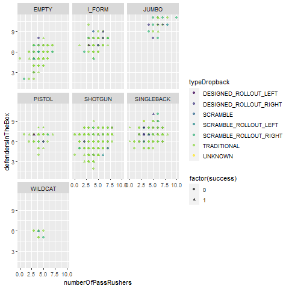

Учитывая, что пасы результативны в 32% случаях на графике видны в основном нерезультативные. Но даже в таком случае можно сказать какое распределение игроков будет наилучшим.

Выбор наилучшего распределения защитников происходит в зависимости от построения атаки ‘offenseFormation’ и расстояния в ярдах до зоны тачдауна для атакующей команды.

```r
plays_s <- read.csv('plays_split.csv', header = TRUE, sep=',')

stat <- plays_s
stat <- subset(stat, !is.na(defendersInTheBox))
stat <- subset(stat, !is.na(numberOfPassRushers))
stat <- subset(stat, offenseFormation != '')
stat <- subset(stat, typeDropback != '')

stat$counts <- 1
stat$yardFromDefTouch <- 0
stat$yardFromDefTouch <- stat$yardlineNumber
stat$yardFromDefTouch[stat$possessionTeam == stat$yardlineSide] <- (100 - stat$yardlineNumber)

stat$success <- 0
stat$success[stat$playResult >= stat$yardsToGo] <- 1

stat$yard_zone <- 1
stat$yard_zone[stat$yardFromDefTouch<80] <- 2
stat$yard_zone[stat$yardFromDefTouch<40] <- 3
stat$yard_zone[stat$yardFromDefTouch<20] <- 4

groupColumns = c("offenseFormation","yard_zone", "defendersInTheBox", "numberOfPassRushers", "success")
dataCol = c("counts")

res <- ddply(stat, groupColumns, function(x) colSums(x[dataCol]))

single_grp_form <- aggregate(res$counts, by=list(offenseFormation=res$offenseFormation), FUN=sum)

single_grp_box <- aggregate(res$counts, by=list(defendersInTheBox=res$defendersInTheBox), FUN=sum)
single_grp_rush <- aggregate(res$counts, by=list(numberOfPassRushers=res$numberOfPassRushers), FUN=sum)

grouped_def <- aggregate(res$counts, by=list(defendersInTheBox=res$defendersInTheBox, numberOfPassRushers=res$numberOfPassRushers), FUN=sum)

all_grp <- aggregate(res$counts, by=list(offenseFormation=res$offenseFormation,
                                         yard_zone=res$yard_zone,
                                         defendersInTheBox=res$defendersInTheBox,
                                         numberOfPassRushers=res$numberOfPassRushers),
                     FUN=sum)

res <- res %>% rowwise %>% do({
  result = as_data_frame(.)
  result$countsOfFormation = single_grp_form[single_grp_form$offenseFormation == result$offenseFormation, 2]
  result$countOfDefInBox = single_grp_box[single_grp_box$defendersInTheBox == result$defendersInTheBox,2]
  result$countOfRushers = single_grp_rush[single_grp_rush$numberOfPassRushers == result$numberOfPassRushers,2]

  result$totalCountsOFAttack = grouped_def[grouped_def$defendersInTheBox == result$defendersInTheBox &
                                             grouped_def$numberOfPassRushers == result$numberOfPassRushers, 3]

  result$totalAll = all_grp[all_grp$offenseFormation == result$offenseFormation &
                              all_grp$yard_zone == result$yard_zone &
                              all_grp$defendersInTheBox == result$defendersInTheBox &
                              all_grp$numberOfPassRushers == result$numberOfPassRushers, 5]

  result
})

res <- res %>%
  rowwise %>%
  do({
    result = as_data_frame(.)
    result$Percentage = round ( (result$counts/(result$totalAll))*100 , 2)
    result
  })
res <- subset(res, totalCountsOFAttack >= 120)
```

На примере представлен реузльтат работы предсказания для ‘ofeenseFormation’ = ‘EMPTY’ и ‘yardFromDefTouch’ = 54

```r
question_ofeenseFormation <- 'EMPTY'
question_yardLineNumber <- 54

question_yard_zone <- 1
question_yard_zone[stat$yardFromDefTouch<80] <- 2
question_yard_zone[stat$yardFromDefTouch<40] <- 3
question_yard_zone[stat$yardFromDefTouch<20] <- 4

if (question_yardLineNumber >= 80){
    question_yard_zone <- 1
} else if (question_yardLineNumber < 80 && question_yardLineNumber > 40){
    question_yard_zone <- 2
} else if (question_yardLineNumber <= 40 && question_yardLineNumber > 20){
    question_yard_zone <- 3
}  else if (question_yardLineNumber <= 20){
    question_yard_zone <- 4 }

answer <- res[ which(res$offenseFormation==question_ofeenseFormation
                         & res$yard_zone == question_yard_zone), ]

answer <- answer[ which(answer$counts > 10), ]
answer <- answer[order(answer$success,-answer$Percentage, -answer$counts),]
answer <- answer[c(1,3,4,12)]
head(answer[1:4] , 3)
```

```
## # A tibble: 3 x 4
## # Rowwise:
##   offenseFormation defendersInTheBox numberOfPassRushers Percentage
##   <chr>                        <int>               <int>      <dbl>
## 1 EMPTY                            4                   3       78.4
## 2 EMPTY                            4                   4       71.5
## 3 EMPTY                            5                   4       69.5
```

### Анализы передачи пасов

Основным критерием по набору очков в атаки, является успешные передачи пасса. Перед вбросом мяча в игру, event = ‘ball_snap’, команда атаки выбирает комбинацию, которую они будут разыгрывать. Но не всегда получается разыграть заранее подготовленную комбинацию из-за действий защиты. QB при получении мяча анализирует поле и пытается принять наиболее правильное решение. По имеющимся данным был проведен анализ, что в большей части влияет на результат паса.

На графике нанесенно распрделение пасов на дистанции от результата которая добилась команда атаки. По цветам распределны результаты паса (‘event’):

- pass_arrived - пас был успешно пойман игроком защиты
- pass_outcome_incomplete - пас не был пойман, мяч улетел в аут
- pass_tipped - пас перехвачен
- pass_outcome_caught - пас пойман в ауте
- pass_outcome_interception- пас перехвачен в ауте

```r
plays_s <- read.csv('plays_split.csv', header = TRUE, sep=',')

plays_s <- subset(plays_s, !is.na(defendersInTheBox))
plays_s <- subset(plays_s, !is.na(numberOfPassRushers))
plays_s <- subset(plays_s, offenseFormation != '')
plays_s <- subset(plays_s, typeDropback != '')

plays_s$counts <- 1
plays_s$yardFromDefTouch <- 0
plays_s$yardFromDefTouch <- plays_s$yardlineNumber
plays_s$yardFromDefTouch[plays_s$possessionTeam == plays_s$yardlineSide] <- (100 - plays_s$yardlineNumber)
```

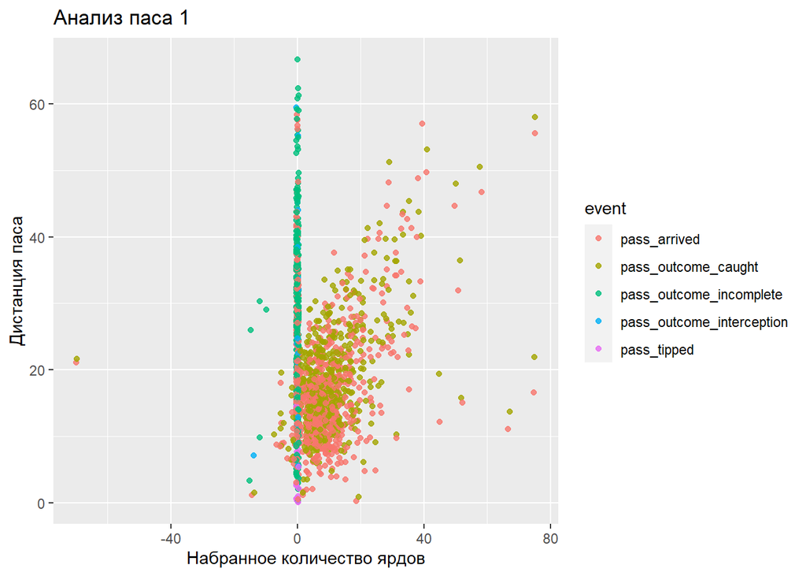

```r
plays_s$success <- 0
plays_s$success[plays_s$playResult >= plays_s$yardsToGo] <- 1

plays_s$yard_zone <- 1
plays_s$yard_zone[plays_s$yardFromDefTouch<80] <- 2
plays_s$yard_zone[plays_s$yardFromDefTouch<40] <- 3
plays_s$yard_zone[plays_s$yardFromDefTouch<20] <- 4

week1 <- read.csv('week1.csv', header = TRUE, sep=',')
week1 <- data.frame(week1)

week_dist_ball <- sqldf("select w2.event, w.event pass_type, w.playId, w.x xs, w.y ys, w2.x xe, w2.y ye, p.offenseFormation, p.typeDropback, p.defendersInTheBox,
  p.numberOfPassRushers, p.playResult, w2.gameId, p.absoluteYardlineNumber, p.yardsToGo,
  p.possessionTeam, w.playDirection, p.down from week1 w
    left JOIN week1 w2 on w2.playId = w.playId and w2.gameId = w.gameId
    JOIN plays_s p ON p.playId = w.playId and p.gameId = w.gameId
    where (w.event = 'pass_forward' or w.event='pass_shovel') and
    (w2.event='pass_arrived' or w2.event='pass_tipped' or w2.event='pass_outcome_caught'
    or w2.event='pass_outcome_interception' or w2.event='pass_outcome_incomplete')
    and w.displayName='Football' and w2.displayName='Football'")

week_dist_ball$dist <- sqrt((week_dist_ball$xs - week_dist_ball$xe)*(week_dist_ball$xs - week_dist_ball$xe) +
                              (week_dist_ball$ys - week_dist_ball$ye)*(week_dist_ball$ys - week_dist_ball$ye))

week_dist_ball <- subset(week_dist_ball, offenseFormation != '')
week_dist_ball <- subset(week_dist_ball, typeDropback != '')

ggplot(data = week_dist_ball, aes(x = (playResult), y = dist)) +
  geom_point(aes(color=(event)), alpha = 0.8, position = 'jitter') +
  labs(color="event", x="Набранное количество ярдов", y="Дистанция паса",title="Анализ паса 1")
```

На графике “Анализ паса 2” показана зависимость дистанция паса от расстояния до зоны тачдауна. Предполагалось что, чем дальше атакующая команда находится от зоны тачдауна, то дистанция паса увеличится, так как команде атаки нужно набирать больше очков и проходить больше ярдов. Оказалось, что это не так. Процентное соотношение успешности паса составляет 32%. Команде атаке нет смысла рисковать дальними пасами и лучше отдавать успешные передачи на малое расстояние.

Количество успешных (1) и не успешных пасов (0)

```r
table(pass_res$pass_suc)
```

```
##
##    0    1
## 1146  530
```

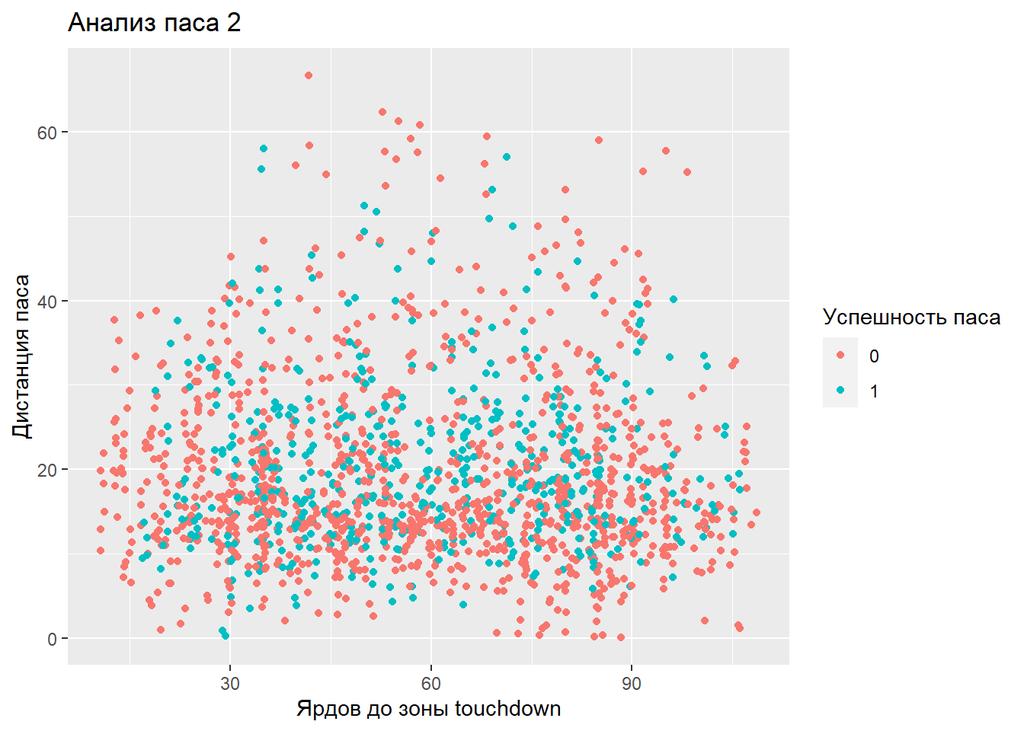

```r
ggplot(data = pass_res, aes(x = (absoluteYardlineNumber), y = dist)) +
  geom_point(aes(color=as.factor(pass_suc)), alpha = 1, position = 'jitter') +
  labs(color="Успешность паса", x="Ярдов до зоны touchdown", y="Дистанция паса", title="Анализ паса 2")
```

Следующая страница

Предыдущая страница